Skip to main content

# Reflection Symmetry

Reflections — Simple Visual Examples

Change

Canonical Movements

Immunity

Groups

Published

July 26, 2026

Modified

November 28, 2026

## Reflection Symmetry

Mirror symmetry is usually explored across a *reference* **line** (often the vertical or horizontal axis). In contrast to **rotation**, this reference line *lies in the same plane as the 2D shape* under consideration!

How do we define this mathematically?

A `Reflection Set` would have just two entries:

$$\mathbb{R}_{𝑛} = \{ {e,m} \}
\tag{1}$$

because $m^2 = e$; the mirror image of a mirror image is the original object.

As a matrix, we can write the reflection operation in a similar way compared to rotation: We use a *reference mirror line*, and flip the object to “the other side” of the mirror. We naturally specify that this *reference mirror line* is at an angle $\theta$ wrt to our $X-axis$. So, in 2D, reflection through a line that makes an angle $\theta$ with the positive $x$-axis is given by the matrix

$$R_{\text{ref}}(\theta)
=
\begin{pmatrix}
\cos 2\theta & \sin 2\theta \\
\sin 2\theta & -\cos 2\theta
\end{pmatrix}
\tag{2}$$

Special cases:

Reflection across the $x$-axis ($\theta = 0$):
$$\begin{pmatrix} 1 & 0 \\ 0 & -1 \end{pmatrix}$$
Reflection across the $y$-axis ($\theta = 90^\circ$):
$$\begin{pmatrix} -1 & 0 \\ 0 & 1 \end{pmatrix}$$
Reflection across the line $y = x$ ($\theta = 45^\circ$):
$$\begin{pmatrix} 0 & 1 \\ 1 & 0 \end{pmatrix}$$
These matrices are `orthogonal` with determinant $-1$, which is the algebraic signature of a reflection.

## R example

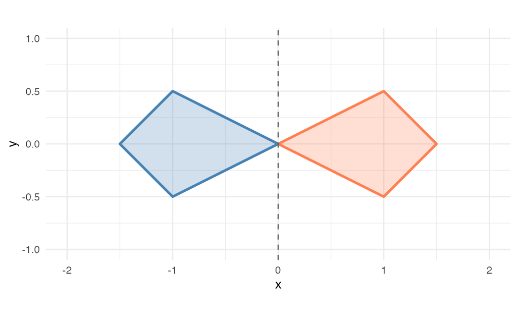

Figure 1: A shape and its mirror image (outlines + light fill)

## Design Notes

- **Rotational only** ($\mathbb{Z}_{n}$): swirling, pinwheel-like, no mirror lines.
- **Reflection only** ($\mathbb{R}_{𝑛} = \{ {e,m} \}$: bilateral balance (faces, logos, architecture).
- **Dihedral** ($\mathbb{D}_{n}$ ): the most common decorative symmetry (snowflakes, flowers, rose windows, tiles).

These geometric ideas become the constraints we later impose on iterative and random processes.

Back to top